# Case Study - Image Classification using Deep CNN in Keras.

# Defining batch size, number of epochs and Layers in model

```python
# Set the batch size, number of epochs.
batch_size = 32
num_classes = 12
epochs = 50
num_predictions = 20
```

```python
# Set the CNN model

model = models.Sequential()

model.add(layers.Conv2D(32, (5, 5), padding='same', activation="relu", input_shape=X_train.shape[1:]))
model.add(layers.BatchNormalization(axis=3))
model.add(layers.MaxPooling2D((2, 2)))
model.add(layers.Dropout(0.2))

model.add(layers.Conv2D(64, (5, 5), padding='same', activation="relu"))
model.add(layers.BatchNormalization(axis=3))
model.add(layers.MaxPooling2D((2, 2)))
model.add(layers.Dropout(0.3))

model.add(layers.Conv2D(64, (3, 3), padding='same', activation="relu"))
model.add(layers.BatchNormalization(axis=3))
model.add(layers.MaxPooling2D((2, 2)))
model.add(layers.Dropout(0.4))

model.add(layers.Conv2D(64, (3, 3), padding='same', activation="relu"))
model.add(layers.BatchNormalization(axis=3))
model.add(layers.MaxPooling2D((2, 2)))
model.add(layers.Dropout(0.5))

model.add(layers.GlobalMaxPooling2D())
model.add(layers.Dense(256, activation="relu"))
model.add(layers.Dropout(0.5))
model.add(layers.Dense(12, activation="softmax"))

model.summary()
```

```
Model: "sequential_1"
_________________________________________________________________
Layer (type)                 Output Shape              Param #
=================================================================
conv2d_4 (Conv2D)            (None, 128, 128, 32)      2432
_________________________________________________________________
batch_normalization_4 (Batch (None, 128, 128, 32)      128
_________________________________________________________________
max_pooling2d_4 (MaxPooling2 (None, 64, 64, 32)        0
_________________________________________________________________
dropout_5 (Dropout)          (None, 64, 64, 32)        0
_________________________________________________________________
conv2d_5 (Conv2D)            (None, 64, 64, 64)        51264
_________________________________________________________________
batch_normalization_5 (Batch (None, 64, 64, 64)        256
_________________________________________________________________
max_pooling2d_5 (MaxPooling2 (None, 32, 32, 64)        0
_________________________________________________________________
dropout_6 (Dropout)          (None, 32, 32, 64)        0
_________________________________________________________________
conv2d_6 (Conv2D)            (None, 32, 32, 64)        36928
_________________________________________________________________
batch_normalization_6 (Batch (None, 32, 32, 64)        256
_________________________________________________________________
max_pooling2d_6 (MaxPooling2 (None, 16, 16, 64)        0
_________________________________________________________________
dropout_7 (Dropout)          (None, 16, 16, 64)        0
_________________________________________________________________
conv2d_7 (Conv2D)            (None, 16, 16, 64)        36928
_________________________________________________________________
batch_normalization_7 (Batch (None, 16, 16, 64)        256
_________________________________________________________________
max_pooling2d_7 (MaxPooling2 (None, 8, 8, 64)          0
_________________________________________________________________
dropout_8 (Dropout)          (None, 8, 8, 64)          0
_________________________________________________________________
global_max_pooling2d_1 (Glob (None, 64)                0
_________________________________________________________________
dense_2 (Dense)              (None, 256)               16640
_________________________________________________________________
dropout_9 (Dropout)          (None, 256)               0
_________________________________________________________________
dense_3 (Dense)              (None, 12)                3084
=================================================================
Total params: 148,172
Trainable params: 147,724
Non-trainable params: 448
_________________________________________________________________
```

# Set optimizer and loss function.

```python
# initiate Adam optimizer
opt = optimizers.Adam(learning_rate=0.001, beta_1=0.9, beta_2=0.999, epsilon=1e-08)
```

```python
# Let's train the model using RMSprop
model.compile(loss='categorical_crossentropy',
              optimizer=opt,
              metrics=['accuracy'])
```

# Defining early stopping and model check point

```python
#Adding Early stopping callback to the fit function is going to stop the training,
#if the val_loss is not going to change even '0.001' for more than 10 continous epochs
from tensorflow.keras.callbacks import ModelCheckpoint, EarlyStopping

early_stopping = EarlyStopping(monitor='val_loss', min_delta=0.001, patience=10)

#Adding Model Checkpoint callback to the fit function is going to save the weights whenever val_loss achieves a new low value.
#Hence saving the best weights occurred during training

model_checkpoint =  ModelCheckpoint('cifar_cnn_checkpoint_{epoch:02d}_loss{val_loss:.4f}.h5',
                                                           monitor='val_loss',
                                                           verbose=1,
                                                           save_best_only=True,
                                                           save_weights_only=True,
                                                           mode='auto',
                                                           period=1)
```

```
WARNING:tensorflow:`period` argument is deprecated. Please use `save_freq` to specify the frequency in number of batches seen.
```

## Fit the model: We can fit this model with 50 epochs and a batch size of 32.

```
Epoch 00001: val_loss improved from inf to 2.50895, saving model to cifar_cnn_checkpoint_01_loss2.5090.h5
Epoch 00002: val_loss did not improve from 2.50895
Epoch 00003: val_loss did not improve from 2.50895
Epoch 00004: val_loss did not improve from 2.50895
Epoch 00005: val_loss improved from 2.50895 to 2.50241, saving model to cifar_cnn_checkpoint_05_loss2.5024.h5
Epoch 00006: val_loss improved from 2.50241 to 1.90347, saving model to cifar_cnn_checkpoint_06_loss1.9035.h5
Epoch 00007: val_loss improved from 1.90347 to 1.64001, saving model to cifar_cnn_checkpoint_07_loss1.6400.h5
Epoch 00008: val_loss did not improve from 1.64001
Epoch 00009: val_loss improved from 1.64001 to 1.61038, saving model to cifar_cnn_checkpoint_09_loss1.6104.h5
Epoch 00010: val_loss improved from 1.61038 to 1.18209, saving model to cifar_cnn_checkpoint_10_loss1.1821.h5
Epoch 00011: val_loss did not improve from 1.18209
Epoch 00012: val_loss did not improve from 1.18209
Epoch 00013: val_loss improved from 1.18209 to 1.00514, saving model to cifar_cnn_checkpoint_13_loss1.0051.h5
Epoch 00014: val_loss did not improve from 1.00514
Epoch 00015: val_loss did not improve from 1.00514
Epoch 00016: val_loss did not improve from 1.00514
Epoch 00017: val_loss improved from 1.00514 to 0.92669, saving model to cifar_cnn_checkpoint_17_loss0.9267.h5
Epoch 00018: val_loss improved from 0.92669 to 0.88606, saving model to cifar_cnn_checkpoint_18_loss0.8861.h5
Epoch 00019: val_loss improved from 0.88606 to 0.81988, saving model to cifar_cnn_checkpoint_19_loss0.8199.h5
Epoch 00020: val_loss did not improve from 0.81988
Epoch 00021: val_loss improved from 0.81988 to 0.80474, saving model to cifar_cnn_checkpoint_21_loss0.8047.h5
Epoch 00022: val_loss did not improve from 0.80474
Epoch 00023: val_loss did not improve from 0.80474
Epoch 00024: val_loss improved from 0.80474 to 0.68932, saving model to cifar_cnn_checkpoint_24_loss0.6893.h5
Epoch 00025: val_loss did not improve from 0.68932
Epoch 00026: val_loss improved from 0.68932 to 0.59402, saving model to cifar_cnn_checkpoint_26_loss0.5940.h5
Epoch 00027: val_loss did not improve from 0.59402
Epoch 00028: val_loss improved from 0.59402 to 0.58794, saving model to cifar_cnn_checkpoint_28_loss0.5879.h5
Epoch 00029: val_loss did not improve from 0.58794
Epoch 00030: val_loss improved from 0.58794 to 0.55192, saving model to cifar_cnn_checkpoint_30_loss0.5519.h5
Epoch 00031: val_loss improved from 0.55192 to 0.52804, saving model to cifar_cnn_checkpoint_31_loss0.5280.h5
Epoch 00032: val_loss did not improve from 0.52804
Epoch 00033: val_loss did not improve from 0.52804
Epoch 00034: val_loss did not improve from 0.52804
Epoch 00035: val_loss did not improve from 0.52804
Epoch 00036: val_loss did not improve from 0.52804
Epoch 00037: val_loss improved from 0.52804 to 0.47591, saving model to cifar_cnn_checkpoint_37_loss0.4759.h5
Epoch 00038: val_loss did not improve from 0.47591
Epoch 00039: val_loss did not improve from 0.47591
Epoch 00040: val_loss did not improve from 0.47591
Epoch 00041: val_loss improved from 0.47591 to 0.43220, saving model to cifar_cnn_checkpoint_41_loss0.4322.h5
Epoch 00042: val_loss did not improve from 0.43220
Epoch 00043: val_loss improved from 0.43220 to 0.42060, saving model to cifar_cnn_checkpoint_43_loss0.4206.h5
Epoch 00044: val_loss did not improve from 0.42060
Epoch 00045: val_loss did not improve from 0.42060
Epoch 00046: val_loss did not improve from 0.42060
Epoch 00047: val_loss did not improve from 0.42060
Epoch 00048: val_loss did not improve from 0.42060
Epoch 00049: val_loss did not improve from 0.42060
Epoch 00050: val_loss improved from 0.42060 to 0.40348, saving model to cifar_cnn_checkpoint_50_loss0.4035.h5
```

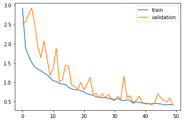

```python
history = model.fit(X_train,
                    Y_train,
                    batch_size=batch_size,
                    epochs=epochs,
                    validation_data=(X_val, Y_val),
                    shuffle=True,
                    verbose=1,
                    callbacks=[early_stopping,model_checkpoint])

# plot training history
plt.plot(history.history['loss'], label='train')
plt.plot(history.history['val_loss'], label='validation')
plt.legend()
plt.show()
```

## Model Score: Once the model is fit, we evaluate it on the validation dataset and print out the classification accuracy which is 88%

```python
# Score trained model.
scores = model.evaluate(X_val, Y_val, verbose=1)
print('Validation loss:', scores[0])
print('Validation accuracy:', scores[1])
```

```
Validation loss: 0.40347832441329956
Validation accuracy: 0.887798011302948
```

# Visualize predictions

```python
pred = model.predict(X_test)
```

```python
predNum = np.argmax(pred, axis=1)
```

```python
for i in np.array([2,3,33,36,59,60,100,202,201]):
  image = X_test[i]
  test_label = Y_test[i]
  pred_label = predNum[i]
  print(f'\n Test Label Id: {test_label} \n Predicted Label Id: {pred_label} \n Predicted Label Name: {label_dict[pred_label]}')
```

```
 Test Label Id: [0 0 0 0 0 0 0 1 0 0 0 0]
 Predicted Label Id: 7
 Predicted Label Name: Scentless Mayweed

 Test Label Id: [0 0 0 0 0 0 0 0 1 0 0 0]
 Predicted Label Id: 8
 Predicted Label Name: Sugar beet

 Test Label Id: [0 1 0 0 0 0 0 0 0 0 0 0]
 Predicted Label Id: 1
 Predicted Label Name: Fat Hen

 Test Label Id: [0 0 0 0 0 0 1 0 0 0 0 0]
 Predicted Label Id: 6
 Predicted Label Name: Cleavers

 Test Label Id: [0 0 0 1 0 0 0 0 0 0 0 0]
 Predicted Label Id: 3
 Predicted Label Name: Common wheat

 Test Label Id: [0 0 0 0 0 0 0 0 0 0 1 0]
 Predicted Label Id: 10
 Predicted Label Name: Black-grass

 Test Label Id: [0 0 0 0 0 0 0 0 1 0 0 0]
 Predicted Label Id: 8
 Predicted Label Name: Sugar beet

 Test Label Id: [0 0 0 1 0 0 0 0 0 0 0 0]
 Predicted Label Id: 8
 Predicted Label Name: Sugar beet

 Test Label Id: [0 0 0 1 0 0 0 0 0 0 0 0]
 Predicted Label Id: 3
 Predicted Label Name: Common wheat
```

# Confusion Matrix

The confusion matrix is one of the best ways to analyse the errors in the model. It gives the exact number of correct and incorrect predictions

```python
y_class = np.argmax(pred, axis = 1)
y_check = np.argmax(Y_test, axis = 1)

cmatrix = confusion_matrix(y_check, y_class)
print(cmatrix)
```

```
[[ 9  0  0  0  3  1 29  0  0  0  0  0]
 [ 0 54  4  0  0  0  0  0  1  0  1  0]
 [ 0  0 34  0  0  0  0  0  1  0  2  0]
 [ 0  0  0 72  0  0  1  0  3  1  4  0]
 [ 1  0  4  0 25  1  1  0  0  0  1  0]
 [ 0  0  1  0  0 71  5  0  0  0  2  0]
 [ 4  0  0  0  1  2 86  0  0  0  0  0]
 [ 0  4  0  0  0  0  0 25  0  0  9  0]
 [ 0  0  1  0  0  1  0  0 87  0  2  0]
 [ 0  0  0  0  0  0  0  0  3 36  1  0]
 [ 0  0  1  0  0  0  0  0  0  0 68  0]
 [ 0  0  0  0  0  0  0  1  2  0  1 45]]
```